# Beta Diversity

09-Jun-2025

**Organisation:** Data Science Platform  
**Responsibles:** Alberto Pallejà Caro (apca@biosustain.dtu.dk)  
Andres Sebastian Ayala Ruano (asaru@dtu.dk)  
Juliana Assis (jasge@dtu.dk)

This markdown is to calculate Bray-Curtis dissimilarities between samples based on species abundance and to plot these ones on the two first axis of a principal coordinate analysis (PCoA).

🔄 Beta Diversity: Bray-Curtis Dissimilarity & PCoA

**Beta diversity** measures **differences in community composition between samples**. It captures how similar or dissimilar samples are in terms of their species or taxa abundance.

**📏 Bray-Curtis Dissimilarity**

The **Bray-Curtis dissimilarity** is a widely used metric in ecology and microbiome analysis. It compares species abundances between two samples and ranges from **0** (identical composition) to **1** (completely different).

$$BC_{ij} = \frac{\sum |x_{ik} - x_{jk}|}{\sum (x_{ik} + x_{jk})}$$

Where: - $x_{ik}$ is the abundance of species *k* in sample *i*, - $x_{jk}$ is the abundance of species *k* in sample *j*.

**🧭 Principal Coordinates Analysis (PCoA)**

To **visualize** the dissimilarity between samples, we use **Principal Coordinates Analysis (PCoA)**. This method projects the dissimilarity matrix into a lower-dimensional space (typically 2D), allowing us to:

- Explore **patterns** in microbial communities.
- Identify **clustering** by experimental groups (e.g., treatment, timepoint).
- Detect **outliers** in community composition.

**🎯 Goal**

- **Input**: A table of species abundances per sample.
- **Step 1**: Compute **Bray-Curtis dissimilarity** between all sample pairs.
- **Step 2**: Perform **PCoA** on the distance matrix.
- **Output**: A 2D scatter plot where:
  - Each point = a sample.
  - Distance between points = ecological dissimilarity.

# 1 R Packages that need to be installed

```r
library(dplyr)
library(ggplot2)
library(vegan)
```

# 2 Load data objects

**Load species abundance, taxonomical annotation and metadata file**

```r
# Abundance table
abundance <- readRDS(file = "../data/MetaphlanAbundance_Species.rds")
rownames(abundance) <- gsub("_SRR_db1.metaphlan", "", rownames(abundance))
dim(abundance)
```

```
## [1]  18 293
```

```r
# Taxonomical annotation
annotation <- readRDS(file = "../data/MetaphlanAnnotations_Species.rds")
dim(annotation)
```

```
## [1] 293   7
```

```r
# Metadata
metadata <- read.table(file = "../data/metadata.tsv",
                       header = TRUE, sep = "\t",
                       quote = "",
                       row.names = NULL)
rownames(metadata) <- metadata$Sample
dim(metadata)
```

```
## [1] 18 21
```

```r
# Take only samples with sequencing and metadata information
abundance <- abundance[rownames(metadata), ]
dim(abundance)
```

```
## [1]  18 293
```

# 3 Creating a directory for the PCoA related results

```r
results_dir <- "results/report/02_Beta-diversity"

dir.create(results_dir, recursive = TRUE, showWarnings = FALSE)
```

## 3.1 Plotting a Principal coordinates analysis (PCoA)

**Step 1: Calculate Bray-Curtis Dissimilarity Matrix**

```r
bray_curtis <- vegdist(abundance, method = "bray")
```

## 3.2 Step 2: Perform PCoA

```r
pcoa_result <- cmdscale(bray_curtis, eig = TRUE, k = 2)
```

## 3.3 Extract eigenvalues and points

**Only positive eigenvalues contribute to variance explained**

```r
eig_vals <- pcoa_result$eig
eig_vals <- eig_vals[eig_vals > 0]
var_explained <- eig_vals / sum(eig_vals)
axis_variance <- round(var_explained[1:2] * 100)

scores <- as.data.frame(pcoa_result$points)
scores$Area <- metadata$Area
scores$Sampling <- metadata$Sampling
colnames(scores) <- c("Axis1", "Axis2", "Area", "Sampling")
```

## 3.4 Step 3: Extract loading data

To calculate variable loadings (contributions of the original variables to the PCoA axes), you can use the envfit() function in the vegan package. Fit environmental vectors to the ordination

```r
loadings <- envfit(pcoa_result, abundance, perm = 999)

loadings_df <- as.data.frame(loadings$vectors$arrows[loadings$vectors$r >= 0.75 &
            loadings$vectors$pvals <= 0.05,])
colnames(loadings_df) <- c("Axis1", "Axis2")
```

## 3.5 Step 4: Plot PCoA results

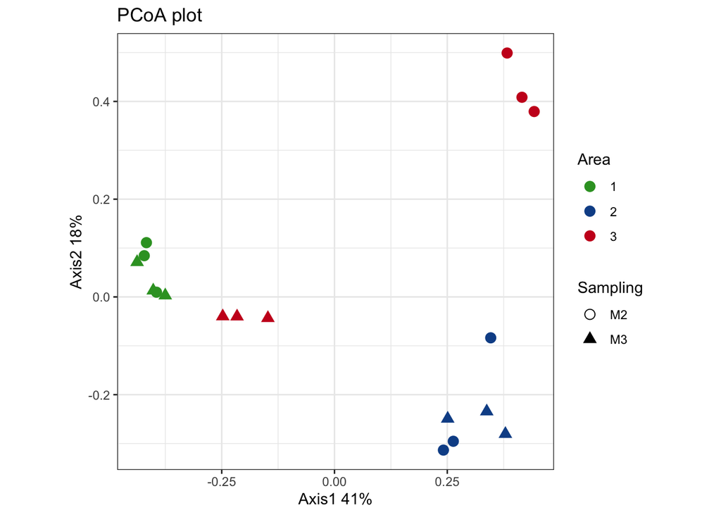

```r
colors <- c("1" = "#349F2C",
            "2" = "#0F5096",
            "3" = "#CA0020")
scores$Area <- as.factor(scores$Area) # as a factor

shapes <- c("M2" = 21,
            "M3" = 17)
scores$Sampling <- as.factor(scores$Sampling) # as a factor

p <- ggplot(scores, aes(x = Axis1, y = Axis2)) +
  geom_point(aes(color = Area, fill = Area, shape = Sampling), size = 3) +
  scale_color_manual(values = colors) +
  scale_fill_manual(values = colors) +
  scale_shape_manual(values = shapes) +
  theme_bw() +
  theme(aspect.ratio = 1) +
  labs(x = paste0("Axis1 ", axis_variance[1], "%"),
       y = paste0("Axis2 ", axis_variance[2], "%"),
       title = "PCoA plot")
p
```

```r
# Save it as a png
ggsave("results/report/02_Beta-diversity/01_PCoA_plot.png",
       width = 8, height = 6, dpi = 300)
```

## 3.6 Step 5: Plot the PCoA with Loadings (optional)

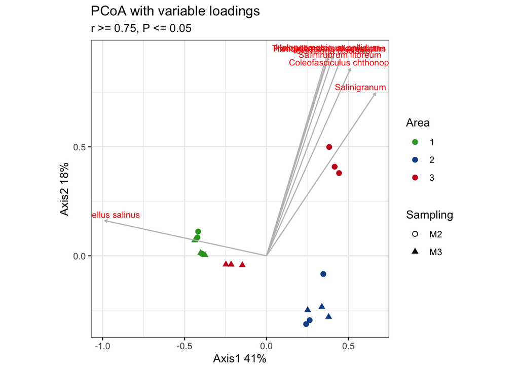

```r
p <- ggplot(scores, aes(x = Axis1, y = Axis2)) +
  geom_point(aes(color = Area, fill = Area, shape = Sampling), size = 2) +
  geom_segment(data = loadings_df,
               aes(x = 0, y = 0, xend = Axis1, yend = Axis2),
               arrow = arrow(length = unit(0.1, "cm")), color = "grey",
               linewidth = 0.5) +
  geom_text(data = loadings_df, aes(x = Axis1, y = Axis2,
            label = annotation$species[match(rownames(loadings_df),
            rownames(annotation))]),
            vjust = -0.5,
            hjust = 0.5,
            color = "red",
            position = "jitter",
            size = 3) +
  scale_color_manual(values = colors) +
  scale_fill_manual(values = colors) +
  scale_shape_manual(values = shapes) +
  theme_bw() +
  theme(aspect.ratio = 1) +
  labs(x = paste0("Axis1 ", axis_variance[1], "%"),
       y = paste0("Axis2 ", axis_variance[2], "%"),
       title = "PCoA with variable loadings",
       subtitle = "r >= 0.75, P <= 0.05")
p
```

```r
# Save it as a png
ggsave("results/report/02_Beta-diversity/02_PCoA_with_loadings.png",
       width = 8, height = 6, dpi = 300)
```

# 4 Permutational multivariate analysis of variance (PERMANOVA)

Before running a PERMANOVA test let’s assess the data dispersion within the areas and within sampling dates. High dispersion of data within the groups could affect the analysis of variance test as this test assumes homogeneity of variance

**Dispersion for Area**

## 4.1 Distance to centroid (dispersion)

```r
dispersion <- betadisper(d = bray_curtis,
                         group = metadata$Area,
                         type = "centroid",
                         bias.adjust = FALSE)
dispersion_table <- permutest(dispersion,
                              permutations = how(nperm = 1000),
                              by = "margin")

dispersion_table
```

```
##
## Permutation test for homogeneity of multivariate dispersions
## Permutation: free
## Number of permutations: 1000
##
## Response: Distances
##           Df   Sum Sq  Mean Sq      F N.Perm   Pr(>F)
## Groups     2 0.110772 0.055386 18.988   1000 0.000999 ***
## Residuals 15 0.043753 0.002917
## ---
## Signif. codes:  0 '***' 0.001 '**' 0.01 '*' 0.05 '.' 0.1 ' ' 1
```

**There is a significant dispersion of the data points among the areas**

### 4.1.1 Dispersion boxplots

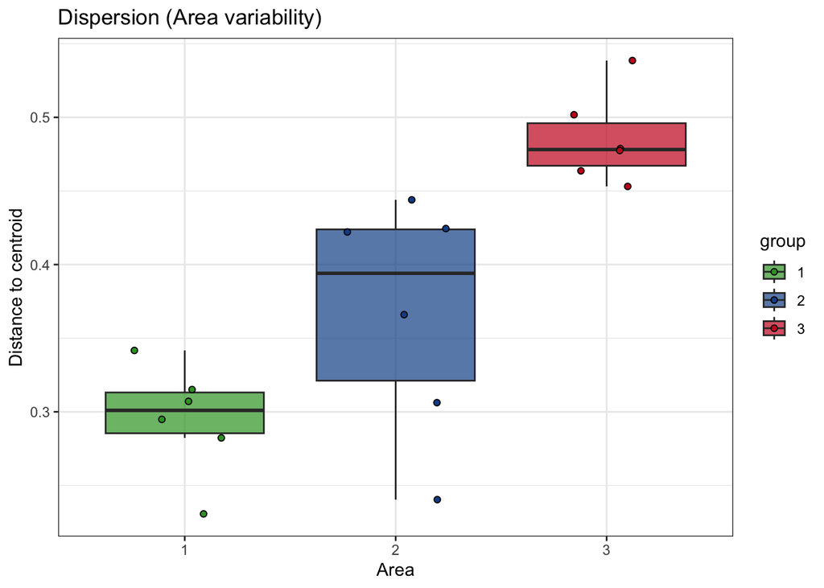

```r
dispersion_plot_data <- data.frame("distance" = dispersion$distances,
                                   "group" = dispersion$group)

dispersion_box <- ggplot(dispersion_plot_data, aes(x = group, y = distance)) +
  geom_boxplot(aes(fill = group), outliers = FALSE, alpha = 0.7) +
  geom_point(aes(fill = group), shape = 21,
             position = position_jitter(width = 0.25, height = 0)) +
  theme_bw() +
  scale_fill_manual(values = colors) +
  labs(title = "Dispersion (Area variability)",
       x = "Area",
       y = "Distance to centroid")

dispersion_box
```

```r
# Save it as a png
ggsave("results/report/02_Beta-diversity/03_dispersion_plot.png",
       width = 6, height = 4, dpi = 300)
```

## 4.2 Dispersion for Sampling

**Distance to centroid (dispersion)**

```r
dispersion <- betadisper(d = bray_curtis,
                         group = metadata$Sampling,
                         type = "centroid",
                         bias.adjust = FALSE)
dispersion_table <- permutest(dispersion,
                              permutations = how(nperm = 1000),
                              by = "margin")

dispersion_table
```

```
##
## Permutation test for homogeneity of multivariate dispersions
## Permutation: free
## Number of permutations: 1000
##
## Response: Distances
##           Df   Sum Sq   Mean Sq      F N.Perm  Pr(>F)
## Groups     1 0.016488 0.0164884 7.6488   1000 0.01099 *
## Residuals 16 0.034491 0.0021557
## ---
## Signif. codes:  0 '***' 0.001 '**' 0.01 '*' 0.05 '.' 0.1 ' ' 1
```

**There is a significant dispersion of the data points between the sampling dates**

### 4.2.1 Dispersion boxplots

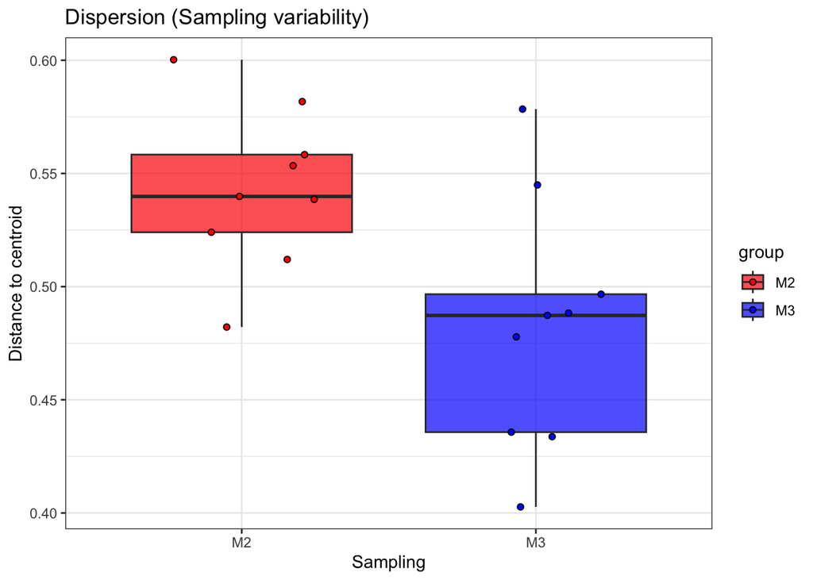

```r
dispersion_plot_data <- data.frame("distance" = dispersion$distances,
                                   "group" = dispersion$group)

dispersion_box <- ggplot(dispersion_plot_data, aes(x = group, y = distance)) +
  geom_boxplot(aes(fill = group), outliers = FALSE, alpha = 0.7) +
  geom_point(aes(fill = group), shape = 21,
             position = position_jitter(width = 0.25, height = 0)) +
  theme_bw() +
  scale_fill_manual(values = c("red", "blue")) +
  labs(title = "Dispersion (Sampling variability)",
       x = "Sampling",
       y = "Distance to centroid")

dispersion_box
```

```r
# Save it as a png
ggsave("results/report/02_Beta-diversity/04_dispersion_plot_sampling.png",
       width = 5, height = 4, dpi = 300)
```

# 5 PERMANOVA test

A significant permutest from a betadisper object indicates that there are significant differences in dispersion among groups, which violates the assumption of homogeneity of variances required for PERMANOVA. You can still perform a PERMANOVA, but the results should be interpreted with caution, and you should consider additional analyses.

**Differences among treatment groups**

```r
set.seed(12)


independent_variables <- paste("Area", "Sampling", sep = "+")

form <- paste0("bray_curtis ~", independent_variables) %>% as.formula
form
```

```
## bray_curtis ~ Area + Sampling
## <environment: 0x121d02240>
```

```r
adonis_table <- adonis2(form,
                        data = metadata,
                        permutations = 1000,
                        by = "margin")

adonis_table
```

|  | Df | SumOfSqs | R2 | F | Pr(>F) |
| --- | --- | --- | --- | --- | --- |
| Area | 1 | 1.2340634 | 0.2275100 | 5.205674 | 0.002997003 |
| Sampling | 1 | 0.6342344 | 0.1169265 | 2.675404 | 0.026973027 |
| Residual | 15 | 3.5559181 | 0.6555635 | NA | NA |
| Total | 17 | 5.4242159 | 1.0000000 | NA | NA |

```r
write.csv(adonis_table,
          file = "results/report/02_Beta-diversity/05_Adonis_table.csv",
          row.names = TRUE, quote = FALSE)
```